# DiaryBiome: downstream analysis of yogurt and dietary supplement metagenomes

2025-07-10

# Data Import and Filtering

## Import & Metadata Integration

Loading the microbial abundance table produced during preprocessing step and associated sample metadata. The metadata was cleaned and reformatted to retain key variables, including sample identifiers and food type categories (e.g., yogurt or supplement).

```r
# Importing abundance matrix
abundance_data <- read.delim(config$input$abundance_file,
                            sep = "\t", header = TRUE, stringsAsFactors = FALSE)
metadata <- read.csv(config$input$metadata_file,
                     header = TRUE, stringsAsFactors = FALSE)

# Clean up metadata for analysis
metadata_clean <- data.frame(
  sample_id = metadata$Run,
  food_type = metadata$isolation_source,
  sample_name = metadata$Sample.Name,
  stringsAsFactors = FALSE
)

print(head(abundance_data[, 1:5]))
```

```
##                        taxon taxon_id SRR11605259 SRR11605260 SRR11605261
## 1 Streptococcus thermophilus     1308     6812769     6789948     6141986
## 2   Streptococcus salivarius     1304        6562        5610        2862
## 3 Streptococcus vestibularis     1343        1186        1294        1106
## 4     Streptococcus parasuis  1501662         367         686          75
## 5         Streptococcus suis     1307         261         280          60
## 6        Streptococcus mitis    28037         212         184         178
```

```r
print(head(metadata_clean))
```

```
##     sample_id          food_type sample_name
## 1 SRR11605259             yogurt        Y009
## 2 SRR11605260             yogurt        Y008
## 3 SRR11605261             yogurt        Y007
## 4 SRR11605262 dietary supplement       DS002
## 5 SRR11605263 dietary supplement       DS001
## 6 SRR11605264             yogurt        Y006
```

Filtered out non-target taxa such as human DNA, viruses, and bacteriophages from the abundance table to focus the analysis on bacterial and fungal communities. We then calculated the number of reads per sample before and after filtering to assess the impact of this step.

```r
# Calculate reads before filtering
reads_before <- colSums(abundance_data[, -c(1,2)])

# Create a list of taxa to remove (non-bacterial/fungal)
taxa_to_remove <- c(
  "Homo sapiens",
  "Respirovirus laryngotracheitidis",
  "Lactococcus phage ul36",
  "Lactococcus phage 98201",
  "Lactococcus phage Tuc2009",
  "Streptococcus phage CHPC577",
  "Lactococcus phage r1t",
  "Sandinevirus BK5T",
  "Streptococcus phage TP-778L",
  "Brussowvirus ALQ132",
  "Slopekvirus pht4A",
  "Slopekvirus eap3",
  "Rosenblumvirus CSA13",
  "Avian coronavirus"
)

# Filter the abundance table
filtered_abundance <- abundance_data %>%
  filter(!taxon %in% taxa_to_remove)

# Calculate reads after filtering
reads_after <- colSums(filtered_abundance[, -c(1,2)])

# Create comparison table
filtering_summary <- data.frame(
  sample_id = names(reads_before),
  reads_before = reads_before,
  reads_after = reads_after,
  reads_removed = reads_before - reads_after,
  percent_removed = round((reads_before - reads_after) / reads_before * 100, 2)
) %>%
  left_join(metadata_clean, by = "sample_id")

cat("Read filtering summary:\n")
```

```
## Read filtering summary:
```

```r
print(filtering_summary)
```

```
##      sample_id reads_before reads_after reads_removed percent_removed
## 1  SRR11605259      6932184     6932040           144            0.00
## 2  SRR11605260      7541945     7541813           132            0.00
## 3  SRR11605261      6207989     6207962            27            0.00
## 4  SRR11605262      1482804     1455343         27461            1.85
## 5  SRR11605263      7458381     7458371            10            0.00
## 6  SRR11605264      8945007     8944004          1003            0.01
## 7  SRR11605265      5626796     5626774            22            0.00
## 8  SRR11605266      7282655     7269357         13298            0.18
## 9  SRR11605267      4539362     4538750           612            0.01
## 10 SRR11605268      4990951     4990605           346            0.01
## 11 SRR11605269      4566441     4562731          3710            0.08
## 12 SRR11605270      7613468     7613442            26            0.00
## 13 SRR11605271      6849340     6849277            63            0.00
## 14 SRR11605272      6843837     6843655           182            0.00
```

[output cut: 19 more lines]

# Alpha Diversity Analysis

## Calculate Richness and Diversity Indices

We constructed a phyloseq object by combining the filtered abundance matrix, taxonomic annotations, and sample metadata. This integrated structure simplifies microbiome data handling and allows seamless downstream analysis of alpha and beta diversity. The phyloseq R package is a widely adopted tool in microbial ecology ([McMurdie & Holmes, 2013](https://journals.plos.org/plosone/article?id=10.1371/journal.pone.0061217)).

```r
# Create phyloseq object for diversity analysis
# Extract abundance matrix
abundance_matrix <- filtered_abundance %>%
  select(-taxon, -taxon_id) %>%
  as.matrix()

# Create taxon table
taxon_table <- filtered_abundance %>%
  select(taxon, taxon_id) %>%
  mutate(OTU = paste0("OTU_", row_number())) %>%
  select(OTU, taxon, taxon_id)

# Create sample data
sample_data <- metadata_clean
rownames(sample_data) <- sample_data$sample_id
sample_data <- sample_data[, -which(colnames(sample_data) == "sample_id")]

# Create phyloseq object
ps <- phyloseq(
  otu_table(abundance_matrix, taxa_are_rows = TRUE),
  sample_data(sample_data),
  tax_table(as.matrix(taxon_table))
)

# Add sample names
sample_names(ps) <- colnames(abundance_matrix)
taxa_names(ps) <- taxon_table$OTU

ps
```

```
## phyloseq-class experiment-level object
## otu_table()   OTU Table:         [ 612 taxa and 16 samples ]
## sample_data() Sample Data:       [ 16 samples by 2 sample variables ]
## tax_table()   Taxonomy Table:    [ 612 taxa by 3 taxonomic ranks ]
```

We estimated within-sample (alpha) diversity using four common indices—**Observed**, **Shannon**, **Simpson**, and **Fisher**—using the `estimate_richness()` function from the `phyloseq` package. These metrics capture different aspects of community richness and evenness. Shannon and Simpson indices account for both the number and relative abundance of taxa, while the Observed and Fisher indices focus on richness.

```r
alpha_div <- estimate_richness(ps, measures = c("Observed", "Shannon", "Simpson", "Fisher"))
cat("Alpha diversity indices by sample:\n")
```

```
## Alpha diversity indices by sample:
```

```r
print(alpha_div)
```

```
##             Observed    Shannon     Simpson    Fisher
## SRR11605259       39 0.09512638 0.033870854  2.638437
## SRR11605260       44 0.34153963 0.179991558  2.984564
## SRR11605261       55 0.07574259 0.021110875  3.847812
## SRR11605262      254 1.65189549 0.731361722 22.973021
## SRR11605263       61 1.09868586 0.655717925  4.242062
## SRR11605264       92 0.03638580 0.007819330  6.509479
## SRR11605265       72 0.05993940 0.015198416  5.180551
## SRR11605266      233 0.12947785 0.031858266 18.053869
## SRR11605267      117 0.06506408 0.014392926  8.902899
## SRR11605268      108 0.08755255 0.022582869  8.101398
## SRR11605269       99 0.58382921 0.241864805  7.427862
## SRR11605270       47 1.41701194 0.687890184  3.201222
## SRR11605271       69 1.26110882 0.639816365  4.874375
## SRR11605272       51 0.23299542 0.104406669  3.522158
## SRR11605273       67 0.01654163 0.003267001  4.708706
## SRR11605274       74 0.04757814 0.012699961  5.307922
```

Here we visualize results of alpha diversity tests:

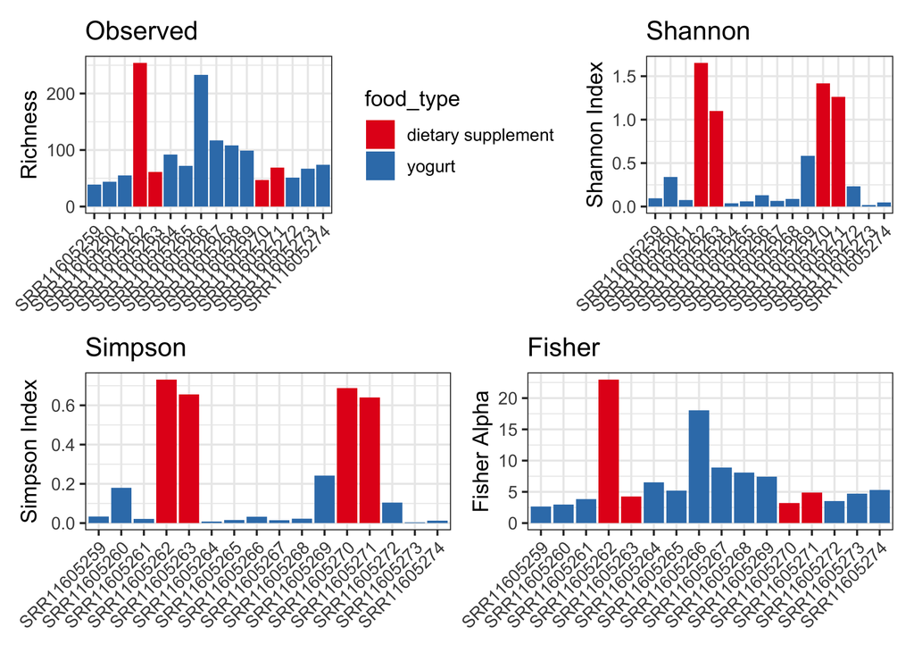

```r
# Add sample metadata
alpha_div$sample_id <- rownames(alpha_div)
alpha_div$food_type <- sample_data(ps)$food_type  # adjust column name

# Build individual ggplot panels
make_plot <- function(metric_name, y_label) {
  ggplot(alpha_div, aes(x = sample_id, y = .data[[metric_name]], fill = food_type, alpha(0.7))) +
    geom_col(position = "dodge") +
    labs(y = y_label, x = NULL, title = metric_name) +
    scale_fill_brewer(palette = "Set1") +
    theme_bw(base_size = 12) +
    theme(axis.text.x = element_text(angle = 45, hjust = 1),
          legend.position = ifelse(metric_name == "Observed", "right", "none"))
}

p_obs     <- make_plot("Observed", "Richness")
p_shannon <- make_plot("Shannon", "Shannon Index")
p_simpson <- make_plot("Simpson", "Simpson Index")
p_fisher  <- make_plot("Fisher", "Fisher Alpha")

# Combine plots using patchwork
layout <- (p_obs | p_shannon) / (p_simpson | p_fisher)

print(layout)
```

## Statistical Testing of Alpha Diversity

To statistically compare alpha diversity between food types, we applied the **Wilcoxon rank-sum test** (also to each diversity index (Observed, Shannon, Simpson, and Fisher). This non-parametric test is suitable for small sample sizes and does not assume normality. This test is appropriate for microbiome data, which often deviate from Gaussian distributions. The results report the W statistic and p-values, with asterisks indicating significant differences (p < 0.05) between groups.

```r
# Wilcoxon test for Observed
obs_wilcox <- wilcox.test(Observed ~ food_type, data = alpha_div)
cat("\n Wilcoxon test for Observed:\n")
```

```
##
##  Wilcoxon test for Observed:
```

```r
cat(sprintf("- W statistic = %.2f\n", obs_wilcox$statistic))
```

```
## - W statistic = 23.00
```

```r
cat(sprintf("- p-value     = %.3g%s\n",
            obs_wilcox$p.value,
            ifelse(obs_wilcox$p.value < 0.05, " *", "")))
```

```
## - p-value     = 0.953
```

```r
# Wilcoxon test for Shannon
shannon_wilcox <- wilcox.test(Shannon ~ food_type, data = alpha_div)
cat("\n Wilcoxon test for Shannon:\n")
```

```
##
##  Wilcoxon test for Shannon:
```

```r
cat(sprintf("- W statistic = %.2f\n", shannon_wilcox$statistic))
```

```
## - W statistic = 48.00
```

```r
cat(sprintf("- p-value     = %.3g%s\n",
            shannon_wilcox$p.value,
            ifelse(shannon_wilcox$p.value < 0.05, " *", "")))
```

```
## - p-value     = 0.0011 *
```

```r
# Wilcoxon test for Simpson
simpson_wilcox <- wilcox.test(Simpson ~ food_type, data = alpha_div)
cat("\n Wilcoxon test for Simpson:\n")
```

```
##
##  Wilcoxon test for Simpson:
```

```r
cat(sprintf("- W statistic = %.2f\n", simpson_wilcox$statistic))
```

```
## - W statistic = 48.00
```

```r
cat(sprintf("- p-value     = %.3g%s\n",
            simpson_wilcox$p.value,
            ifelse(simpson_wilcox$p.value < 0.05, " *", "")))
```

```
## - p-value     = 0.0011 *
```

```r
# Wilcoxon test for Fisher
fisher_wilcox <- wilcox.test(Fisher ~ food_type, data = alpha_div)
cat("\n Wilcoxon test for Fisher:\n")
```

```
##
##  Wilcoxon test for Fisher:
```

```r
cat(sprintf("- W statistic = %.2f\n", fisher_wilcox$statistic))
```

```
## - W statistic = 23.00
```

```r
cat(sprintf("- p-value     = %.3g%s\n",
            fisher_wilcox$p.value,
            ifelse(fisher_wilcox$p.value < 0.05, " *", "")))
```

```
## - p-value     = 0.953
```

# Beta Diversity Analysis

## Bray-Curtis Dissimilarity

To assess differences in microbial community composition **between** samples, we computed the Bray-Curtis dissimilarity matrix using the `phyloseq::distance()` function. Bray-Curtis is a widely used ecological distance metric that considers the abundance of shared and unique taxa between samples.

```r
# Calculate Bray-Curtis dissimilarity matrix
bray_dist <- phyloseq::distance(ps, method = "bray")
bray_dist
```

```
##             SRR11605259 SRR11605260 SRR11605261 SRR11605262 SRR11605263
## SRR11605260  0.04549659
## SRR11605261  0.06070319  0.10234837
## SRR11605262  0.99902687  0.99907549  0.99867681
## SRR11605263  0.99964490  0.99964774  0.99962697  0.99929704
## SRR11605264  0.14011601  0.17466402  0.18828725  0.99894666  0.99966688
## SRR11605265  0.10711075  0.14848207  0.05330343  0.99847334  0.99960597
## SRR11605266  0.03818237  0.08078687  0.08635211  0.99780531  0.99925800
## SRR11605267  0.21193187  0.25172991  0.15971136  0.99786623  0.99954806
## SRR11605268  0.17084439  0.21104722  0.11716169  0.99798788  0.99923624
## SRR11605269  0.29775130  0.33298272  0.25728753  0.99827320  0.99918493
## SRR11605270  0.99993276  0.99992108  0.99497432  0.99981409  0.82149407
## SRR11605271  0.57005996  0.56409042  0.55393204  0.99873348  0.98845149
## SRR11605272  0.04391321  0.04992663  0.05428423  0.99866803  0.99966690
## SRR11605273  0.02920309  0.07267186  0.07726055  0.99893971  0.99967184
## SRR11605274  0.07115181  0.11286965  0.01676781  0.99869708  0.99962207
##             SRR11605264 SRR11605265 SRR11605266 SRR11605267 SRR11605268
## SRR11605260
## SRR11605261
## SRR11605262
## SRR11605263
## SRR11605264
## SRR11605265  0.23000145
## SRR11605266  0.11482191  0.12959678
## SRR11605267  0.32835918  0.10916545  0.23184809
## SRR11605268  0.28931698  0.06699328  0.18642391  0.05001083
## SRR11605269  0.41172060  0.21788468  0.32150437  0.12671905  0.16259430
## SRR11605270  0.99990663  0.99990468  0.99931975  0.99986208  0.99920629
## SRR11605271  0.63806583  0.54024859  0.59397531  0.49791461  0.51664637
## SRR11605272  0.17879820  0.10043095  0.08075087  0.20572691  0.16455799
## SRR11605273  0.11393628  0.12252806  0.01066498  0.22552804  0.18380496
## SRR11605274  0.19933139  0.03781980  0.09726097  0.14453272  0.10202645
##             SRR11605269 SRR11605270 SRR11605271 SRR11605272 SRR11605273
## SRR11605260
## SRR11605261
## SRR11605262
## SRR11605263
## SRR11605264
## SRR11605265
## SRR11605266
## SRR11605267
## SRR11605268
## SRR11605269
## SRR11605270  0.94952207
## SRR11605271  0.43277379  0.90055355
## SRR11605272  0.29229539  0.99993041  0.54195274
## SRR11605273  0.32122004  0.99993566  0.59110174  0.07257321
## SRR11605274  0.24561269  0.99991858  0.55200784  0.06468917  0.08810603
```

We performed **Principal Coordinate Analysis (PCoA)** on the Bray-Curtis dissimilarity matrix to visualize beta diversity among samples in a reduced dimensional space. Using classical multidimensional scaling (`cmdscale`), we extracted the first three principal coordinates and calculated the percentage of variance explained by each axis.

```r
# PCoA analysis
pcoa_result <- cmdscale(bray_dist, k = 3, eig = TRUE)

# Extract coordinates
pcoa_coords <- as.data.frame(pcoa_result$points)
colnames(pcoa_coords) <- c("PCoA1", "PCoA2", "PCoA3")
eigenvals <- pcoa_result$eig
explained_var <- 100 * eigenvals / sum(eigenvals[eigenvals > 0])

# Add sample IDs and join with metadata
pcoa_coords <- pcoa_coords %>%
  tibble::rownames_to_column("sample_id")

pcoa_data <- pcoa_coords %>%
  left_join(metadata_clean, by = "sample_id")

print(head(pcoa_data))
```

```
##     sample_id      PCoA1        PCoA2       PCoA3          food_type
## 1 SRR11605259 -0.1779571  0.003338798  0.04029966             yogurt
## 2 SRR11605260 -0.1729620  0.003545917  0.03945296             yogurt
## 3 SRR11605261 -0.1769069 -0.001363713  0.02258657             yogurt
## 4 SRR11605262  0.5923449  0.632521490 -0.02517876 dietary supplement
## 5 SRR11605263  0.6916925 -0.248652718  0.41303863 dietary supplement
## 6 SRR11605264 -0.1601054  0.012534776  0.07957171             yogurt
##   sample_name
## 1        Y009
## 2        Y008
## 3        Y007
## 4       DS002
## 5       DS001
## 6        Y006
```

Visualization of PCoA results

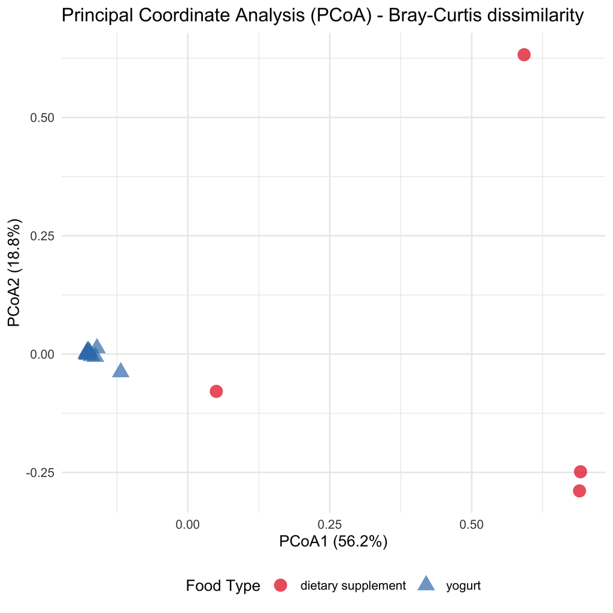

```r
# Create PCoA plot
p_pcoa <- ggplot(pcoa_data, aes(x = PCoA1, y = PCoA2, color = food_type, shape = food_type)) +
  geom_point(size = 4, alpha = 0.7)  +
  scale_color_brewer(palette = "Set1") +
  labs(title = "Principal Coordinate Analysis (PCoA) - Bray-Curtis dissimilarity",
       x = paste0("PCoA1 (", round(explained_var[1], 1), "%)"),
       y = paste0("PCoA2 (", round(explained_var[2], 1), "%)"),
       color = "Food Type",
       shape = "Food Type") +
  theme_minimal() +
  theme(legend.position = "bottom")

print(p_pcoa)
```

## Statistical Testing of Beta Diversity

To statistically assess differences in microbial community composition between food types, we applied **PERMANOVA** (Permutational Multivariate Analysis of Variance) using the `adonis2()` function. This non-parametric test evaluates whether the centroids of sample groups differ significantly in multivariate space, based on the Bray-Curtis dissimilarity matrix.

We additionally tested for **homogeneity of group dispersions** using `betadisper()` to ensure that differences detected by PERMANOVA were not driven by unequal within-group variance. This step helps validate that group differences reflect shifts in community structure rather than dispersion alone.

```r
# Perform PERMANOVA to test for significant differences between food types
permanova_result <- adonis2(bray_dist ~ food_type, data = sample_data)

# Display PERMANOVA results
cat("PERMANOVA Results:\n")
```

```
## PERMANOVA Results:
```

```r
print(permanova_result)
```

```
## Permutation test for adonis under reduced model
## Permutation: free
## Number of permutations: 999
##
## adonis2(formula = bray_dist ~ food_type, data = sample_data)
##          Df SumOfSqs      R2      F Pr(>F)
## Model     1   1.4031 0.47813 12.827  0.002 **
## Residual 14   1.5314 0.52187
## Total    15   2.9346 1.00000
## ---
## Signif. codes:  0 '***' 0.001 '**' 0.01 '*' 0.05 '.' 0.1 ' ' 1
```

```r
# Save PERMANOVA results
permanova_df <- as.data.frame(permanova_result)

# Perform homogeneity of multivariate dispersions test
dispersion_test <- betadisper(bray_dist, sample_data$food_type)
anova_dispersion <- anova(dispersion_test)

cat("\nHomogeneity of Multivariate Dispersions Test:\n")
```

```
##
## Homogeneity of Multivariate Dispersions Test:
```

```r
print(anova_dispersion)
```

```
## Analysis of Variance Table
##
## Response: Distances
##           Df  Sum Sq Mean Sq F value    Pr(>F)
## Groups     1 0.70691 0.70691  130.72 1.736e-08 ***
## Residuals 14 0.07571 0.00541
## ---
## Signif. codes:  0 '***' 0.001 '**' 0.01 '*' 0.05 '.' 0.1 ' ' 1
```

# Differential Abundance Analysis

**ANCOM-BC (Analysis of Compositions of Microbiomes with Bias Correction)** models microbial count data while correcting for compositional bias and unequal sampling depths. It was chosen because of unbiased estimates of log-fold changes (log₂FC) across groups. ANCOM-BC is particularly well-suited for microbiome studies with modest sample sizes and varying library depths, as in our case.

```r
# Prepare data for ANCOM-BC
ancombc_result <- ancombc(ps, formula = "food_type",
                         p_adj_method = "holm",
                         lib_cut = 0,
                        group = "food_type")
```

```r
res_df <- data.frame(
  taxon_id = ancombc_result$res$p_val$taxon,
  log2FC     = ancombc_result$res$lfc$food_typeyogurt,
  SE         = ancombc_result$res$se$food_typeyogurt,
  p_value    = ancombc_result$res$p_val$food_typeyogurt,
  q_value    = ancombc_result$res$q_val$food_typeyogurt,
  significant = ancombc_result$res$diff_abn$food_typeyogurt
)

# Get taxonomy (species names)
tax_df <- as.data.frame(tax_table(ps))
tax_df$taxon_id <- rownames(tax_df)

# Merge for annotation
res_merged <- res_df %>%
  left_join(tax_df, by = "taxon_id") %>%
  select(taxon_id, taxon, log2FC, SE, p_value, q_value, significant) %>%
  arrange(q_value)

# Filter significant taxa
sig_df <- res_merged %>% filter(significant == TRUE)

# Report
cat("### ANCOM-BC Results Summary\n")
```

```
## ### ANCOM-BC Results Summary
```

```r
cat("Total taxa tested:", nrow(res_merged), "\n")
```

```
## Total taxa tested: 229
```

```r
cat("Significant taxa (q < 0.05):", nrow(sig_df), "\n")
```

```
## Significant taxa (q < 0.05): 12
```

```r
cat("Higher in yogurt group (log2FC > 0):", sum(sig_df$log2FC > 0), "\n")
```

```
## Higher in yogurt group (log2FC > 0): 11
```

```r
cat("Higher in supplement group (log2FC < 0):", sum(sig_df$log2FC < 0), "\n")
```

```
## Higher in supplement group (log2FC < 0): 1
```

```r
# Extract species names (or full taxonomy label) of significant taxa
significant_species <- sig_df$taxon

# Print species list
cat("### Significant Taxa (Species Level):\n")
```

```
## ### Significant Taxa (Species Level):
```

```r
cat(paste0("• ", significant_species), sep = "\n")
```

```
## • Streptococcus sobrinus
## • Streptococcus agalactiae
## • Streptococcus parasuis
## • Streptococcus pyogenes
## • Streptococcus macedonicus
## • Streptococcus oriscaviae
## • Streptococcus ratti
## • Streptococcus mitis
## • Lactococcus lactis
## • Streptococcus salivarius
## • Streptococcus sanguinis
## • Bifidobacterium pseudolongum
```